# Spatially Derived Clusters

Spatial transcriptomics

Clustering

Spatial domains

In this lesson, we will discover how BANKSY leverages neighborhood information to cluster spatial transcriptomics data using both gene expression and spatial context. You will compare BANKSY clusters with expression-only methods and evaluate differences in tissue domain detection.

Author

Noor Sohail

Published

July 22, 2025

Keywords

BANKSY, Neighborhoods, Niches, Azimuthal Gabor filter

Approximate time: 40 minutes

## Learning objectives

In this lesson, we will:

- Calculate a BANKSY counts matrix which incorporates neighborhood structure
- Run Harmony integration
- Evaluate spatially-constrained clusters

## Overview of lesson

At this point in the analysis, we have clusters and UMAP coordinates calculated based **solely upon the gene expression**. As this is a spatial dataset, we also have the ability to incorporate the location of bins, or the neighborhood structure, in the clustering process. Here, we will make use of the BANKSY method that adds the local structure as information to ultimately calculate new clusters that are spatially constrained.

## BANKSY

In the standard single-cell workflow, our clusters are identified solely based upon the similarity of gene expression between bins. However, this approach does not take into account the spatial relationship and how close bins are in proximity to one another. The idea being that we would expect bins of similar expression and cell type to be nearby.

[BANKSY](https://www.nature.com/articles/s41588-024-01664-3) is an algorithm that allows you to calculate scores that consider both the gene expression and spatial proximity of bins to one another. How much consideration can be given to the spatial locations is modulated with a `lambda` value. This `lambda` value controls the balance between gene expression and location.

Therefore, BANKSY is a powerful way to include the full extent of data in our dataset to group bins together.

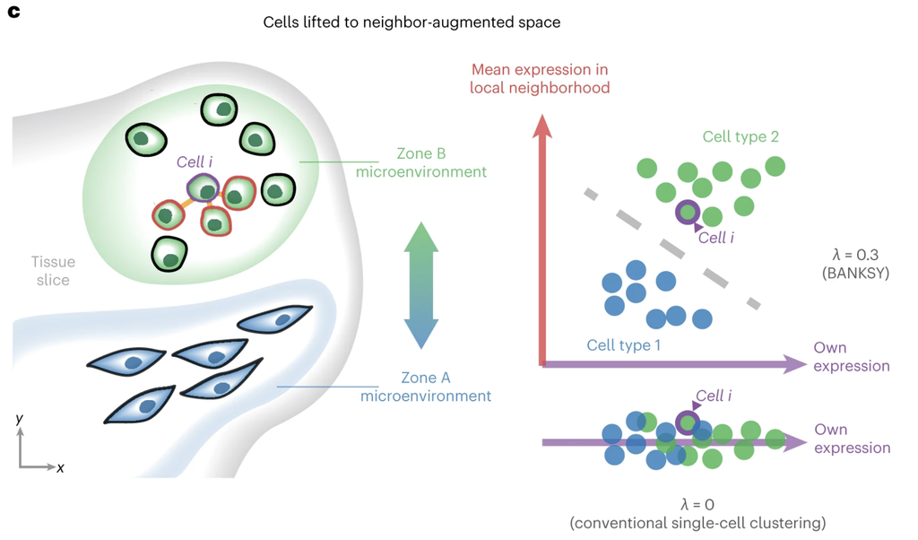

Figure 1: Schematic of how BANKSY identifies cell type clusters based upon both gene expression and spatial proximity.  
*Image source: [Singhar et al. (2024)](https://www.nature.com/articles/s41588-024-01664-3)*

One of the examples used in the original manuscript makes use of the layered structure of the brain’s cortical structure. Here, we can see the differences from the annotated dataset compared to two different methods of clustering. The middle represents clustering based upon solely gene expression, similar to the Leiden clusters we have already calculated. To contrast, the right figure shows clusters generated from BANKSY. We can see that the bins are more cleanly grouped in spatial location.

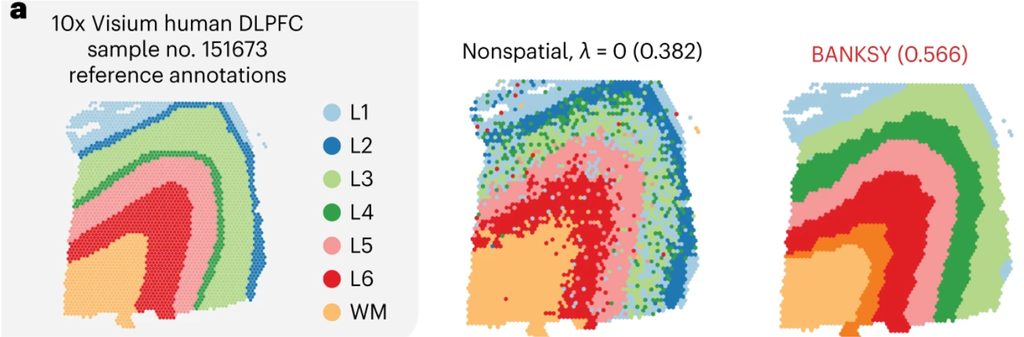

Figure 2: Three different visuals of the brain cortical layers, the left shows the reference annotation, middle is clustering based solely on gene expression, and right shows clusters assigned with BANKSY.  
*Image source: [Singhar et al. (2024)](https://www.nature.com/articles/s41588-024-01664-3)*